# CITESeQC Tutorial

Jie Sun

2025-07-07

In this tutorial, we introduced CITESeQC, the first software package designed for multi-layered, systemic, and quantitative quality control of CITE-seq data. Acknowledging the multi-modal nature of CITE-seq, CITESeQC performs quality control across gene expression, surface protein markers, and their interactions. CITESeQC supports multi-layered QC by offering 7 modules for evaluating RNA or protein data individually, and 5 additional modules for assessing cross-modality relationships, such as RNA–protein consistency.

# Install package and load dependent R packages

```r
#devtools::install_github("sunjie001130/CITESeQC", force = TRUE)
library(CITESeQC)
library(Seurat)
library(hdf5r)
library(tidyverse)
library(SeuratDisk)
library(patchwork)
library(grid)
library(gridExtra)
library(magick)
library(ggplot2)
library(dplyr)
library(celldex)
library(Matrix)
```

# Read the example H5 file and initialize a Seurat object

```r
filePath <- "/ihome/hpark/jis117/CITESEQ/pbmc_10k_protein_v3_filtered_feature_bc_matrix.h5" # change to your own file path
pbmc <- readCITEseqData(filePath)
```

```
## Genome matrix has multiple modalities, returning a list of matrices for this genome
```

# Module 1: RNA_read_corr()

The RNA_read_corr() function generates a scatterplot showing the correlation between the number of unique detected genes (nFeature_RNA) and the total number of RNA molecules (nCount_RNA) per cell.

Users can specify custom cutoff values to identify high-quality cells by passing them as arguments to the function, using cutoff_lo for the lower threshold and cutoff_hi for the upper threshold.

In the example below, red dotted lines indicate the default cutoffs: cells with fewer than 200 or more than 2,500 detected genes will be filtered out in the following steps.

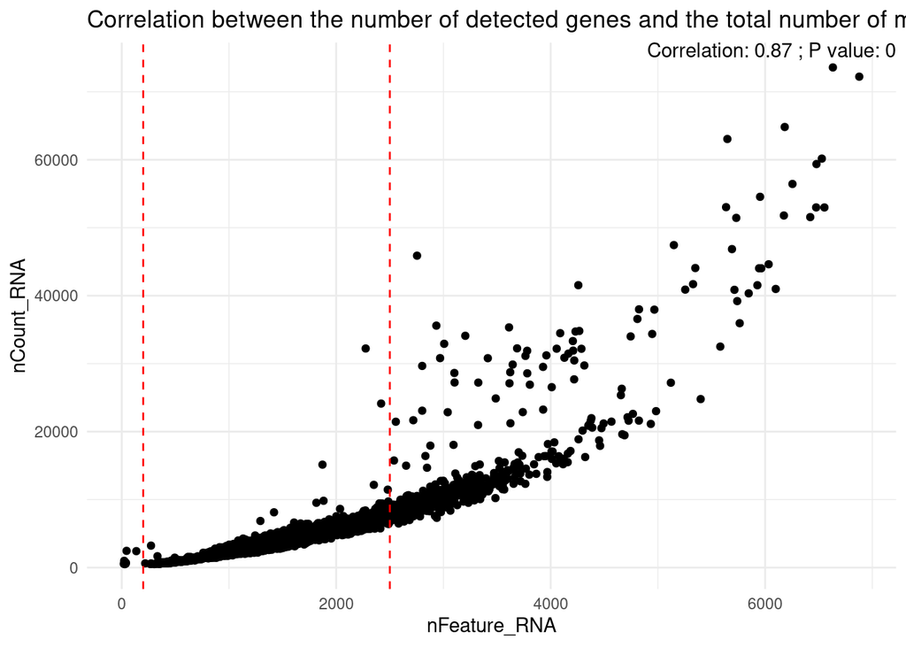

```r
RNA_read_corr(pbmc)
```

# Module 2: ADT_read_corr()

The ADT_read_corr() function generates a scatterplot showing the correlation between the number of detected ADTs and the total number of ADT molecules identified on the cell surface.

Cutoff values for identifying high-quality cells can be passed as arguments to the function and are displayed on the plot, allowing users to adjust them based on their data.

In this example, we do not display any cutoffs for ADTs because the data did not reveal clear quality thresholds, and filtering based on ADT metrics was not always necessary. However, it is still useful to examine the relationship between ADT features and counts.

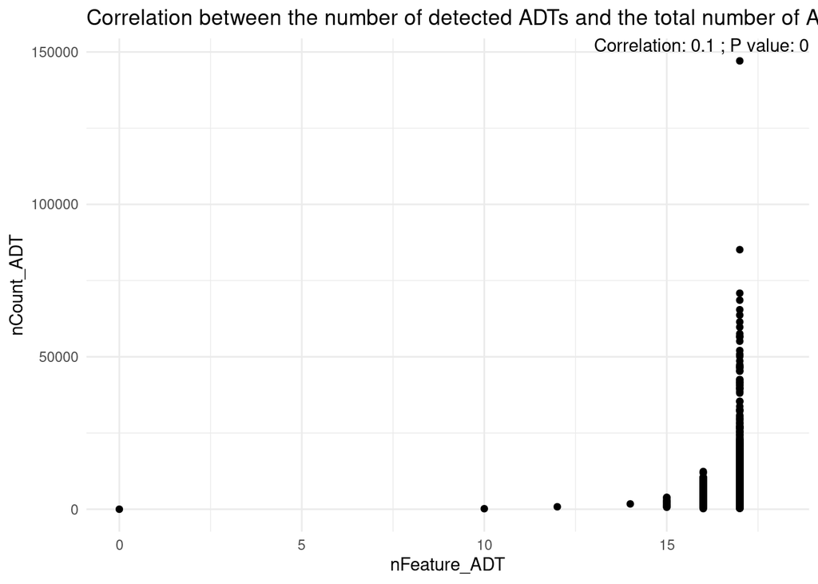

```r
ADT_read_corr(pbmc)
```

# Module 3: RNA_mt_read_corr()

Users can specify custom cutoff values to identify high-quality cells by passing them as arguments to the function. The cutoff_mt parameter sets the threshold above which cells are filtered out based on their mitochondrial content.

In the example below, a red dotted line indicates the default cutoff: cells with more than 10% mitochondrial counts are filtered out.

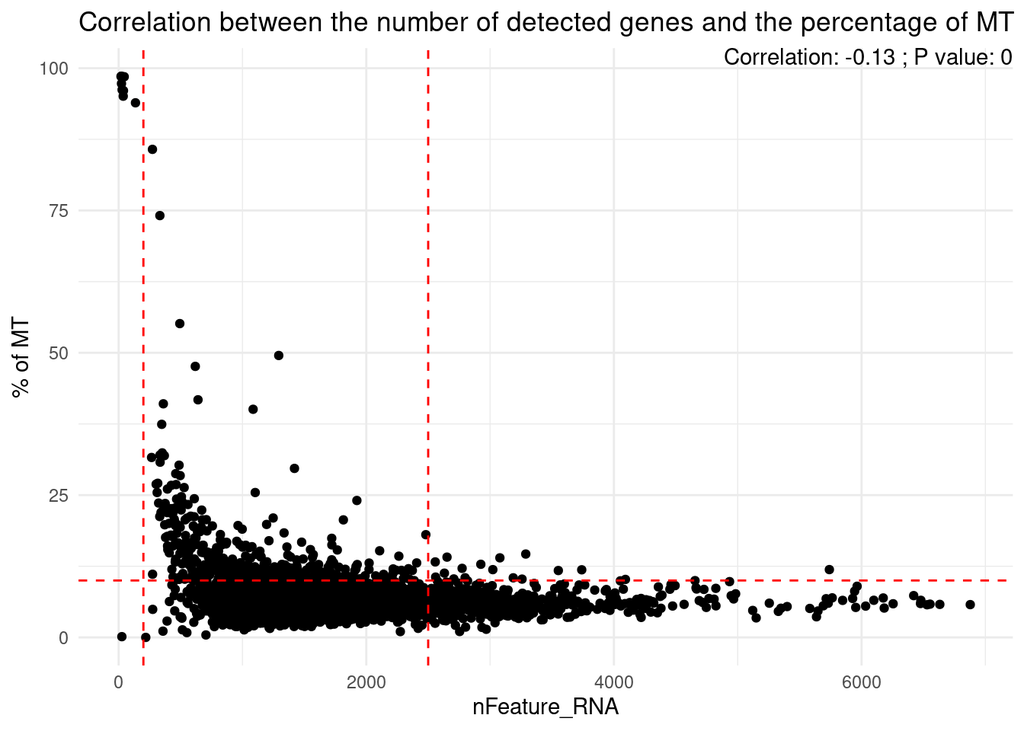

```r
RNA_mt_read_corr(pbmc)
```

## Function pbmc.trim()

This function filters cells based on the user-defined cutoffs provided earlier, the default parameters are feature_cutoff_lo = 200, feature_cutoff_hi = 2500, and mt_cutoff = 10.

If you do not wish to filter any cells, you can simply skip this step.

```r
pbmc.trim <- trimReads(pbmc)
```

## Function def_clust()

def_clust() defines cell clusters either by performing clustering on the input gene expression matrix or by importing a predefined clustering result.

Specifically, it uses Seurat to cluster cells based on the specified resolution and identifies marker genes for each cluster for downstream analysis.

```
## Normalizing layer: counts
```

```
## Finding variable features for layer counts
```

```
## Normalizing across cells
```

# Module 4: RNA_dist()

To enable quantification and comparison, the function calculates Shannon entropy based on the expression distribution across clusters. A lower Shannon entropy value indicates more cluster-specific expression, while a higher value suggests more uniform expression across clusters.

While entropy is not used to filter out cells, it serves as a valuable indicator of expression specificity. This metric can inform downstream analyses and assist in selecting meaningful marker genes. For more details, please refer to our main manuscript. Here we use gene CCR7 as an example.

```r
RNA_dist(pbmc_clust$pbmc, "CCR7")
```

```
## As of Seurat v5, we recommend using AggregateExpression to perform pseudo-bulk analysis.
## First group.by variable `ident` starts with a number, appending `g` to ensure valid variable names
```

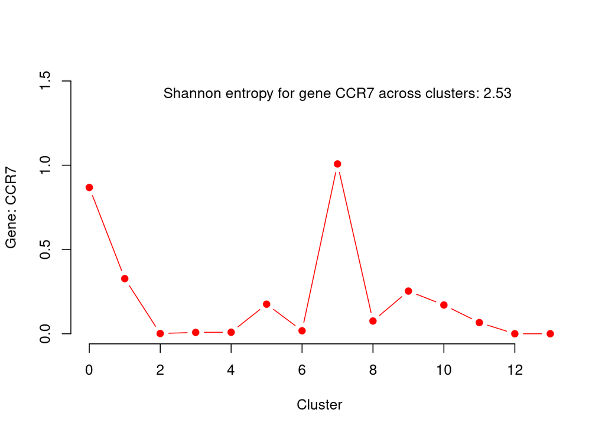

# Module 5: multiRNA_hist()

multiRNA_hist() generates a histogram of Shannon entropy values for the marker genes identified in def_clust(). This visualization reflects how specifically the marker genes are expressed across clusters. A peak at high entropy values suggests that many marker genes lack cluster specificity.

By default, the function uses the top 10 marker genes per cluster, but users can customize this selection to suit their data.

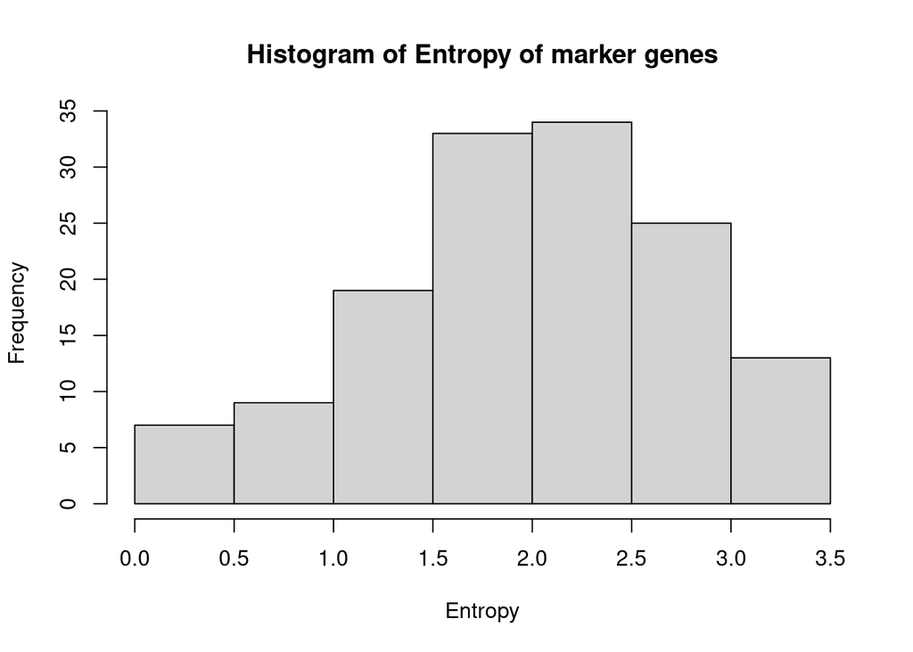

```r
multiRNA_hist(pbmc_clust$pbmc, pbmc_clust$markerListGEX)
```

# Module 6: ADT_dist()

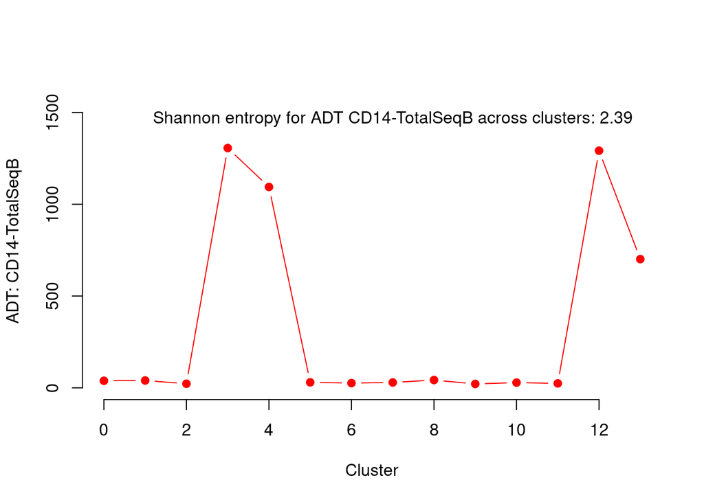

```r
ADT_dist(pbmc_clust$pbmc, "CD14-TotalSeqB")
```

# Module 7: multiADT_hist()

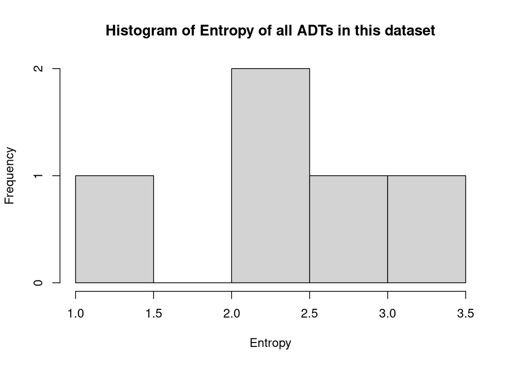

```r
ADTs <- c("CD14-TotalSeqB", "CD4-TotalSeqB", "TIGIT-TotalSeqB", "CD8a-TotalSeqB", "CD19-TotalSeqB")
multiADT_hist(pbmc_clust$pbmc, ADTs)
```

# Module 8: RNA_ADT_read_corr()

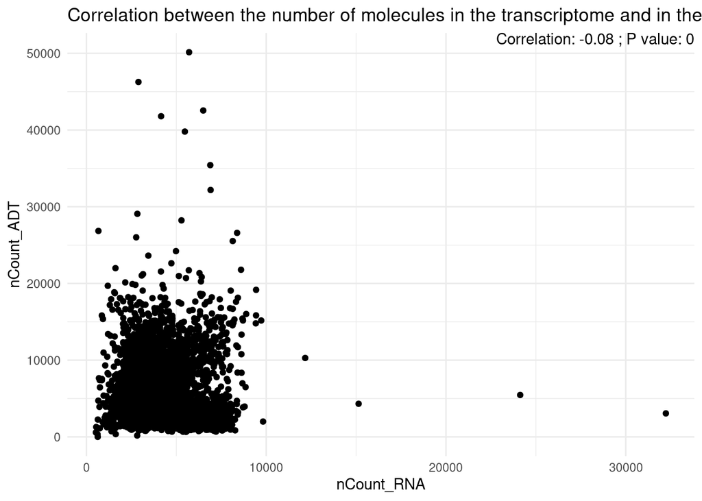

```r
RNA_ADT_read_corr(pbmc_clust$pbmc)
```

# Module 9: RNA_ADT_UMAP_corr()

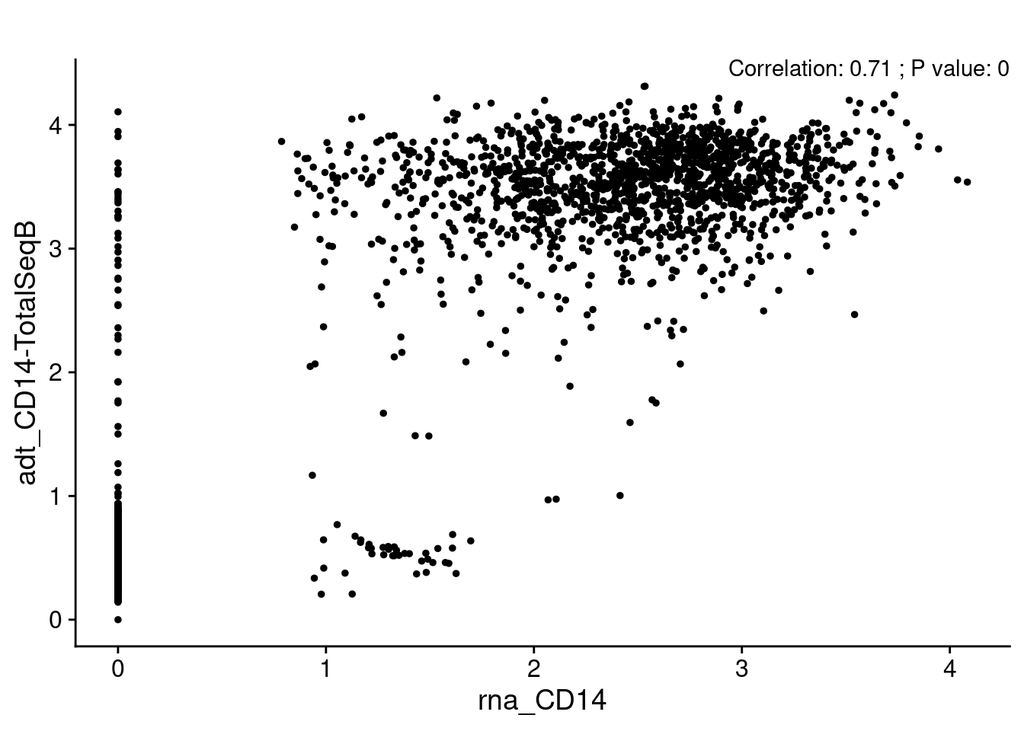

```r
RNA_ADT_UMAP_corr(pbmc_clust$pbmc, "rna_CD14", "adt_CD14-TotalSeqB")
```

# Module 10: RNA_ADT_cluster_corr()

RNA_ADT_cluster_corr() is a set of scatterplots each drawn for each cell cluster, showing the correlation between the input ADT abundance and the corresponding gene expression for the cluster.

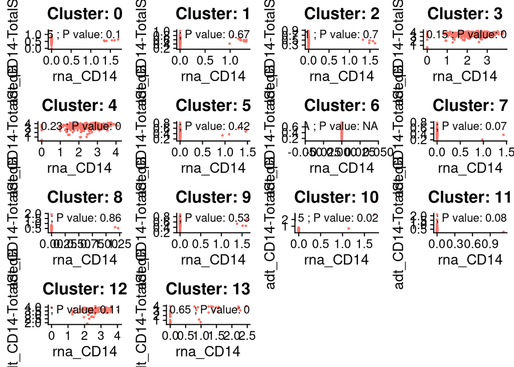

```r
RNA_ADT_cluster_corr(pbmc_clust$pbmc, "rna_CD14", "adt_CD14-TotalSeqB")
```

# Module 11: RNA_ADT_hist()

RNA_ADT_hist() is a histogram of the correlation coefficients in all pairs of ADTs and the corresponding genes in expression.

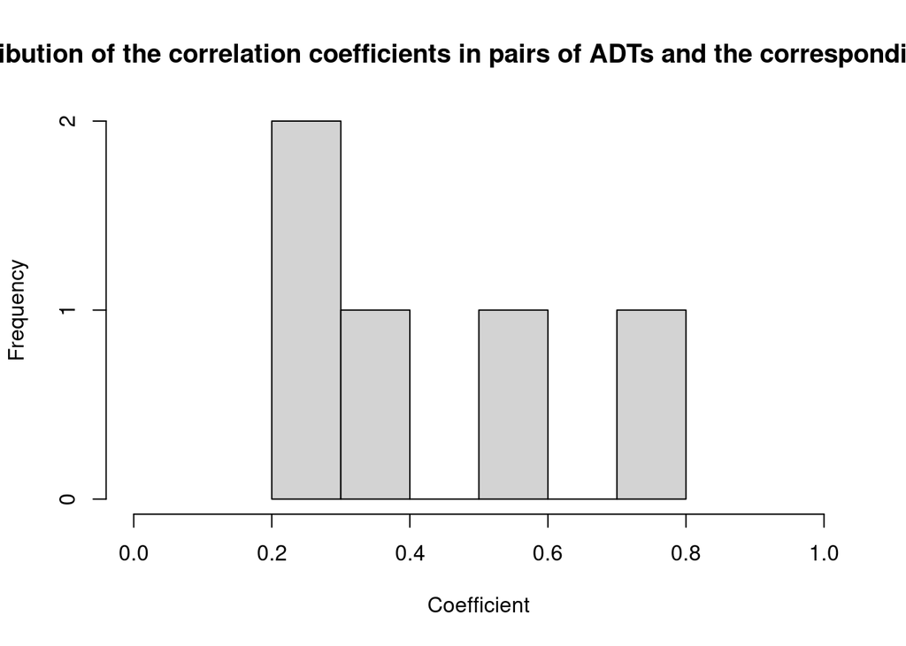

```r
RNA_features <- c('rna_CD14', 'rna_CD4', 'rna_TIGIT', 'rna_CD8A', 'rna_CD19')
ADT_features <- c('adt_CD14-TotalSeqB', 'adt_CD4-TotalSeqB', 'adt_TIGIT-TotalSeqB', 'adt_CD8a-TotalSeqB', 'adt_CD19-TotalSeqB')
RNA_ADT_hist(pbmc_clust$pbmc, RNA_features, ADT_features)
```

# Module 12: RNA_ADT_cluster_hist()

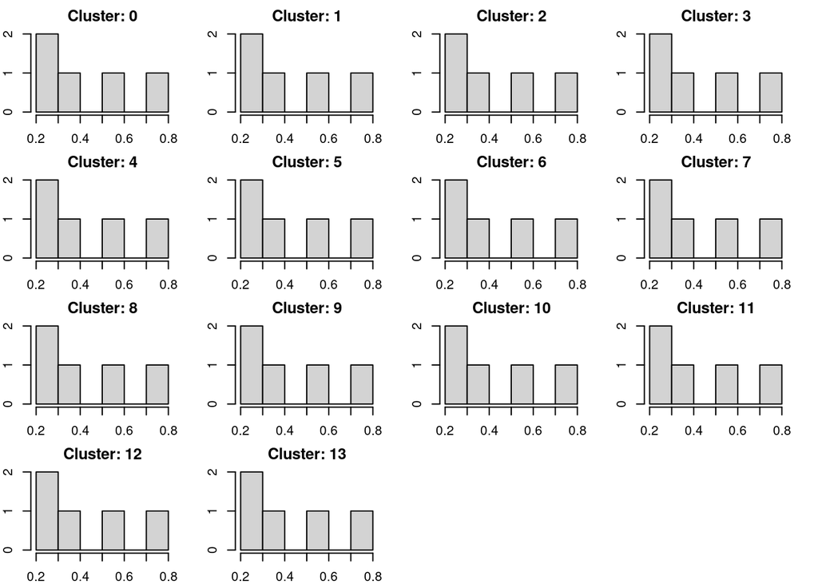

```r
RNA_ADT_cluster_hist(pbmc_clust$pbmc, RNA_features, ADT_features)
```